# Health Care Transition Tool-Kit 2015-2020

# **Topic Introduction**

Title V Maternal and Child Health Bureau Services program recommends addressing Health Care Transition for children, from pediatric to adult health care, between ages 12 years and 22 years. Rigorous efforts have been made since 2015, to develop, assess and implement Health Care Transition (HCT) Initiative in Oklahoma. Provider and family studies are being conducted, on on-going basis to help achieve national performance measures by year 2020. Sooner SUCCESS (State Unified Children’s Comprehensive Exemplary Services for Special Needs) in collaboration with Oklahoma Department of Human Services and partnering agencies, has prepared a toolkit to facilitate community-based outreach and promotion. These measures are intended to advocate awareness among providers and families, especially for children and youth with special health care needs (CYSHCNs) in-order to maximize their life-long functioning and potential via un-interrupted health care services.

This toolkit contains information for providers and caregivers of children and youth with special health care needs and guides them to resources available in the state of Oklahoma and information about topics including health insurance coverage, legal guardianship, foster care, decision making and self-care.These resources should enable the healthcare transition to occur without the burden of missing information, and will provide hope to those individuals who rely a seamless healthcare transition to live happy and healthy lives.

Fig 1:

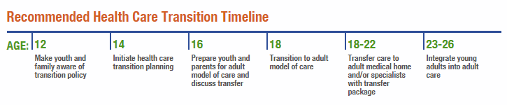

[Source:Got Transition](http://www.gottransition.org/providers/index.cfm)

# **Provider Education**

Linked here is a [Webinar Series](https://cdn.knightlab.com/libs/timeline3/latest/embed/index.html?source=1F6TN-u5gNyaDe-QS7Khz8P50GRRt1xwe4D8oipBsGlQ&font=Default&lang=en&initial_zoom=2&height=800) for Provider Education on the subject of Health Care Transition.

The Webinar Series was downloaded from [Got Transition](https://www.gottransition.org/webinars/index.cfm)

# **Professional Recommendations**

The field of health care transition is constantly expanding and improving. Listed below are resources related to transition research and policy according to Got Transition.

Policy Professional Organization Statements on Transition

- 2018 AAP/AAFP/ACP Clinical Report on Transition [“Supporting the Health Care Transition From Adolescence to Adulthood in the Medical Home”](https://pediatrics.aappublications.org/content/142/5/e20182587)
- 2011 AAP/AAFP/ACP Clinical Report on Transition [“Supporting the Health Care Transition From Adolescence to Adulthood in the Medical Home”](https://pediatrics.aappublications.org/content/pediatrics/early/2011/06/23/peds.2011-0969.full.pdf)
- 2002 AAP/AAFP/ACP Statement [“A Consensus Statement on Health Care Transitions for Young Adults With Special Health Care Needs”](https://pediatrics.aappublications.org/content/110/Supplement_3/1304#:~:text=The%20goal%20of%20transition%20in,moves%20from%20adolescence%20to%20adulthood)
- 1993 Society for Adolescent Medicine Position Paper [“Transition from Child-Centered to Adult Health-Care Systems for Adolescents with Chronic Conditions”](https://www.sciencedirect.com/science/article/pii/1054139X9390143D)

(For more information on Policy development visit : https://www.gottransition.org/researchpolicy/index.cfm )

# **Six Core Elements of Healthcare Transition**

## **Care Policy/Guide**

This element stresses the importance of developing a transition and care policy/guide with the input from youth and parents/caregivers that describes the approach to transition. Included is the need to educate all staff about the approach to transition as well as clearly defining distinct roles of the youth, parent/caregiver, and pediatric and adult health care team in the transition process taking into account cultural preferences. And finally this guide should be displayed where it is accessible and can be discussed further.

## **Tracking and Monitoring**

This element creates the need for proper criteria and processes for identifying transition aged youth to be established. When possible tracking should be integrated into electronic medical records for ease of access.

## **Transition Readiness**

It is very important to assess youth’s transition readiness and self-care skills. Using a standardized tool for transition assessment is a key for engaging youth and their families to set their health priorities and prepare them for an adult approach to care at age 18 and navigating the adult health care system including health insurance.

It is important to note that the point of a transition assessment is not to simply to score an adolescent, but in reality it should generate a dialogue between clinicians and youth and parents/caregivers about the skills needed and then how to learn these skills.  
The organization Got Transition has several transition readiness assessment tools for youth as well as their parents/ caregivers and also for you with intellectual disabilities or developmental disabilities and for their parents/ caregivers.

### **Oklahoma Healthy Transitions Initiative (OHTI)**

The Oklahoma Healthy Initiative (OHTI) focuses on the best efforts of the state of Oklahoma and local level partnerships for youth and young adults ages 16-25 with serious mental health conditions. The information below are helpful tools in order to assists this vulnerable group with transitioning to adulthood.

For more information visit:

[Information about OHTI](https://www.ok.gov/odmhsas/documents/OHTI%20Program%20Overview2.pdf)

OHTI Website

[Transition Assessment for youth](https://www.gottransition.org/resourceGet.cfm?id=239)

[Transition Assement for parents/caregivers](https://www.gottransition.org/resourceGet.cfm?id=240)

We also found related Healthcare Transition Assessment tools which would help further assessment of your child’s readiness for Healthcare Transition. They follow a similar format as mentioned by Got Transition and they are mentioned below for additional information.

[Health Care Advice, Tips, and More](http://tknlyouth.sdsu.edu/worksheets/Healthcare.pdf)

[UIC Transition Milestones skills sheet: Health Care](https://dscc.uic.edu/wp-content/uploads/2013/11/0520-TRANSITION-TOOLKIT-WEB.pdf)

[Transitions-Changing Role for Youth](http://sys.mahec.net/media/brochures/3_changing_role_youth.doc)

### **Condition-Specific Transition Readiness Assessment are also available below**

[Transition Readiness Assessment for youth with Intellectual/Developmental Disiabilities](http://www.acponline.org/sites/default/files/documents/clinical_information/high_value_care/clinician_resources/pediatric_adult_care_transitions/gim_dd/idd_transition_readiness_assessment_for_youth.docx)

Transition Readiness Assessment for Parents/Caregivers of youth with Intellectual/Developmental Disabilities

[Transition Readiness Assessment for youth with Physical Disabilities](http://www.acponline.org/sites/default/files/documents/clinical_information/high_value_care/clinician_resources/pediatric_adult_care_transitions/gim_pd/transition_readiness_assessment_for_youth_final.docx)

Transition Readiness Assessment for Parent/Caregivers of youth with Physical Disabilities

[Transition for youth with Congential Heart Disease](http://www.acponline.org/sites/default/files/documents/clinical_information/high_value_care/clinician_resources/pediatric_adult_care_transitions/chd/chd_transition_readiness_assessment_pediatric_1.docx)

[Transition Readiness Assessment for youth with Type 1 Diabetes Diabetes](https://clinical.diabetesjournals.org/content/early/2019/05/13/cd18-0027)

[Transition Readiness Assessment for youth with Sickle Cell Disease Disease](http://www.acponline.org/sites/default/files/documents/clinical_information/high_value_care/clinician_resources/pediatric_adult_care_transitions/sickle_cell/scd_transition_readiness_assessment.docx)

The Transition Readiness Assessment forms are very important for everyone especially for youth, parents, and providers. It is an integrated approach towards a successful healthcare transition. It includes a range of questions such as, does the child understand his/her basic healthcare needs and disabilities, and can the child express her needs to his/her family and doctors. Majority of the Transition Readiness Assessment is designed to cover and elaborate on questions such as these. But there are some questions such as, if the youth can co-sign his/her consent form, or of the youth can discuss his/her healthcare decisions with their parents, or if the youth can take care of his/her medical equipment, and if the youth knows about his/her health insurance coverage after he/she turns 18. Information to help answers these more difficult questions can be found in different Transition Readiness Assessment Forms provided by organizations such as Got Transition or Universities/Federal Entities.

## **Transition Planning**

The planning element includes making sure that the plan of care includes readiness assessment findings, youths goals, medical summary and emergency care plan. The reason behind this is because it is vital for providers to have all of these documents as well as have a way to regularly update and develop action steps. Preparing the youth for healthcare transition revolves around constantly updating and improving on these resources as well as determining decision-making supports, compiling legal resources, identifying an adult clinician(s) for future care, and obtaining consent from parent/caregiver for release of medical records. It can be daunting at first with the planning element, but as constant updates are made, and communication improved between provider and patient, healthcare transition will occur naturally and smoothly.

## **Transfer of Care**

Transfer of care revolves around understanding what the youth needs, and what avenue can be took to ensure these needs are met. Steps that are essential for transfer of care include, completing transfer package, confirming date of first adult clinician appointment, prepare letter for adult clinician detailing how best assist the youth with special needs, and knowing that sometimes transfer of care dates need to be pushed back because of unforeseen circumstances.

## **Transfer Completion**

The transfer completion element can often be seen as following up on the healthcare transition process. Steps that need to be took include, contacting youth/young adult and parent/caregiver 3-6 months after last pediatric visit to confirm attendance at first adult appointment, communicated with adult practice answering concerns or questions, and lastly building ongoing and collaborative partnerships with adult primary and specialty care clinicians.

# **Condition-Specific Resources**

Similar to the importance of understanding general questions about Transition Resources, it is vitally important to understand how specific health conditions will affect individuals, caregivers/parents, and providers. Listed below are resources that all parties can use to be able to utilize existing resources provided to persons who need assistance or who have additional questions.

## **Cerebral Palsy**

[Resources in Oklahoma](http://www.okdrs.org/guide_07_03m)

[The Little Light House-Cerebral Palsy](https://www.littlelighthouse.org/cerebral-palsy/)

[Cerebral Palsy Resources, CDC](https://www.cdc.gov/ncbddd/cp/links.html)

## **Cystic Fibrosis**

[Cystic Fibrosis Foundation](https://www.cff.org/OKC/)

[Oklahoma State Department of Health- Cystic Fibrosis](https://www.ok.gov/health/Family_Health/Screening_&_Special_Services/Newborn_Screening_Program/Disorders_Screened/Cystic_Fibrosis.html)

[Cystic Fibrosis Resources, Integris](https://integrisok.com/services/medical/cystic-fibrosis)

## **Diabetes**

[Diabetes Overview](https://www.niddk.nih.gov/health-information/diabetes/overview)

[Oklahoma Health Care Authority-Diabetes Resources](http://www.okhca.org/individuals.aspx?id=17197)

[Oklahoma Department of Rehabilitation Services- Diabetes Support Groups](http://www.okdrs.org/guide_13_01g)

## **Intellectual/Developmental Disabilities**

[OKDHS Developmental Disabilties Services](http://www.okdhs.org/services/dd/Pages/default.aspx)

[Developmental Disabilties Resources, CDC](https://www.cdc.gov/ncbddd/developmentaldisabilities/links.html)

[Oklahoma State Department of Education Intellectual Disabilities Resources](https://sde.ok.gov/intellectual-disabilities)

## **Juvenile Arthritis**

[Arthritis Foundation](https://www.arthritis.org/oklahoma/juvenile-arthritis/)

[Arthritis Foundation Transition Webinar](https://www.arthritis.org/juvenile-arthritis/transitions/pediatric-to-adult-medical-care)

[American College of Rheumatology Juvenile Arthritis Resources](https://www.rheumatology.org/I-Am-A/Patient-Caregiver/Diseases-Conditions/Juvenile-Arthritis)

## **Neuromuscular Disease**

[Integris MDA Neuromuscular Center](https://integrisok.com/locations/neuroscience/integris-mda-neuromuscular-center)

[How to find a Disease Specialist](https://rarediseases.info.nih.gov/guides/pages/25/how-to-find-a-disease-specialist)

[Oklahoma Rehabilitation Services Resources](http://www.okdrs.org/guide_13_01n)

## **Spina Bifida**

[Spina Bifida Association](https://www.spinabifidaassociation.org/)

[Saint Francis Spina Bifida Clinic](https://www.saintfrancis.com/services/neurosciences/conditions-we-treat/spine-disorders)

[Spina Bifida Resource Center Oklahoma](https://www.spinabifida.net/spina-bifida-oklahoma.html/)

## **HIV/AIDS**

[Oklahoma HIV/AIDS Resource Guide](https://www.ok.gov/health2/documents/HIV-STDResourceGuide.pdf)

[Oklahoma Department of Rehabilitation Services- HIV/AIDS Resources](http://www.okdrs.org/guide_07_03zd)

[Oklahoma Human Services HIV/AIDs Hotline & Resources](http://www.okdhs.org/services/health/Pages/resources.aspx)

## **Heart Disease**

[OKC- County Health Department My Heart Program](https://www.occhd.org/myheart)

[Oklahoma Heart Institute](https://oklahomaheart.com/resources/understanding-heart-disease#.XtgXmzpKhaQ)

[Find a Doctor, Oklahoma Heart Hospital](https://www.okheart.com/find-a-doctor)

[Mayo Clinic Congnetial Heart Disease Resource](https://www.mayoclinic.org/diseases-conditions/adult-congenital-heart-disease/symptoms-causes/syc-20355456)

## **Cancer**

[Financial Assistance for Cancer Patients in Oklahoma](https://www.fifthseasonfinancial.com/blog/financial-resources-for-cancer-patients-in-oklahoma/)

[Resources for living with cancer](https://www.thisislivingwithcancer.com/get-support?cmp=42bb81fb-166b-483b-8f9c-856913816dd1)

[American Cancer Society in Oklahoma](https://www.cancer.org/about-us/local/oklahoma.html)

## **Mental Health**

[Oklahoma Department of Mental Health and Substance Abuse Services](https://www.ok.gov/odmhsas/Mental_Health/index.html)

[Provider Search and Mental Health Resources](https://www.rtor.org/directory/mental-health-oklahoma/)

[Integris Mental Health Resources](https://integrisok.com/locations/mental-health/integris-mental-health/mental-health-resources)

[Oklahoma Rehabilitation Services, Mental Health Resources](http://www.okdrs.org/guide/05_13)

Understanding information about factors such as Health Insurance, Finding Health Care, Legal aspects in regards to Health Transition and Continuing Education can be greatly beneficial to the process of Health Care Transition. Listed below are resources that should help with this process:

# **Health Insurance**

[Medicare](https://www.medicare.gov/)

[Coverage Options, Healthcare.gov](https://www.healthcare.gov/people-with-disabilities/coverage-options/)

[Benefits and Insurance, USA.gov](https://www.usa.gov/disability-benefits-insurance)

[SoonerCare](http://www.okhca.org/individuals.aspx?id=95&parts=11601)

[UnitedHealthcare Oklahoma Health Insurance Options](https://www.uhc.com/individual-and-family/health-insurance-oklahoma)

[Health Insurance/Financial Aids](https://www.medicalhomeportal.org/living-with-child/navigating-transitions-with-your-child/transition-to-adulthood/health-insurance-financial-aids)

# **Finding Health Care**

## [Medical Home Portal, Finding Adult Health Care](https://www.medicalhomeportal.org/living-with-child/navigating-transitions-with-your-child/transition-to-adulthood/finding-adult-health-care)

- This link provides a helpful guide of steps to take when finding Adult Health Care for Transitioning Individuals

## [Find a Doctor, Integris](https://integrisok.com/doctors)

- Doctors can be looked up by last name, location or specialty who work in the Integris Health System

## [Find a Doctor, OU](https://findadoc.oumedicine.com/)

- Doctors can be looked up by last name, location, and specialty who work in the OU Health System.

## [Find a Doctor, Mercy](https://www.mercy.net/search/doctor/?solrsort=&distance=25&options=&insuranceProviders=&specialties=&servicesOffered=&gender=&languages=&page=1)

- Doctors can be found by name, location, and specialty who work in the Mercy Health System.

## [Find a Doctor, SSM Health](https://www.ssmhealth.com/find-a-doctor)

- Doctors can be searched by name, specialty, and location who work in the SSM Health System.

## [Find a Doctor by Specialty](https://www.healthgrades.com/specialty-directory)

- Doctors can be looked up by specialty in and outside Oklahoma.

## [Physician Compare, Medicare.gov](https://www.medicare.gov/physiciancompare/)

- Government website that lets you compare Doctors in and outside of Oklahoma.

# **Legal aspects of Health Transition**

[Family Resource Guide](http://www.familyresourceguide.org/trans-to-adulthood/pubbenefits-legalissues.aspx)

- Guide created by the Allegheny County in Pennsylvania that lists legal issues that can promote or hinder Health Transition.

[Navigating Healthcare Transitions: Pediatric to Adult Medical Care](https://www.cdlsusa.org/wp-content/uploads/2018/10/NavigatingHealthcareTransitions_ForParentsCaregivers.pdf)

- Comprehensive guide created by the CdLS Foundation that includes Financial and Legal aspects that pertain to Health Transition.

[Transition Health Care Checklist: Preparing for life as an adult](https://www2.waisman.wisc.edu/cedd/pdfs/products/health/THCL.pdf)

- Checklist created by the Wisconsin Community of Practice on Transition that elaborates on Fact Sheets created to solve Financial and Legal Concerns of Health Transition.

# **Continuing Education/ Post Secondary Options**

[Lead, Learn, Live](https://www.leadlearnlive.org/) Link provides resources to Lead, Learn, Live program which assists youth with special needs in career aspirations with regards to post secondary education. The program provides individualized resources for youth to succeed and grow while attending a post secondary institution.

[Think College](https://thinkcollege.net/) Link provides resources about Think College which is a national organization which assists with developing, expanding, and improving resources for people with intellectual disabilities as it pertains to higher education.

[Disability Associated Scholarships and Awards](https://www.eparent.com/special-needs-resource-directory/disability-related-scholarships-awards/) Link provides lists of scholarships that individuals with disabilities would be able to utilize for furthering their education.

[Academic Resources](https://specialedresource.com/special-education-resources-for-adults) Link list Academic Resources that provide adults and youth assistance with furthering their education.

[Transition Guide, Oklahoma Parents Center](https://oklahomaparentscenter.org/youth/transition-school-to-work/) Link provides a guide that assists parents with supporting their loved ones with education past High school.

[Post Secondary Options, Oklahoma Parents Center](https://oklahomaparentscenter.org/youth/post-secondary-options/) Link list options that youth and adults with disabilities could take for furthering education and employment.

# **Provider Information Briefs**

Information Briefs related to healthcare transition that providers would like to know:

[Toolkit for Primary Care Providers treating youth and adults with intellectual or other developmental disabilities](https://inclusivehealth.specialolympics.org/resources/tools/idd-toolkit-for-primary-care-providers)

[Transition to Adult Health Care Services Study, NIH](https://www.ncbi.nlm.nih.gov/pmc/articles/PMC4877694/)

[Physician Experiences Providing Primary Care to Pople with Disabilities Study, NIH](https://www.ncbi.nlm.nih.gov/pmc/articles/PMC2645198/)

[Persons with Disabilities as an Unrecongized Health Disparity Population Study, NIH](https://www.ncbi.nlm.nih.gov/pmc/articles/PMC4355692/)

[Legal Guardianship and Decision-making](https://www.gottransition.org/resourceGet.cfm?id=17)

[Foster Care Transition Toolkit](https://www2.ed.gov/about/inits/ed/foster-care/youth-transition-toolkit.pdf)

[Health Insurance](https://www.gottransition.org/resources/index.cfm#fostercareandtransition)

[Developmental/Behavioral Screening Coding Fact Sheet for Primary Care Providers](https://www.aap.org/en-us/Documents/coding_factsheet_developmentalscreeningtestingandEmotionalBehvioraassessment.pdf)

[Provider Billing and Procedures Manual](https://www.okhca.org/providers.aspx?id=100)

[Oklahoma Work Incentives Planning and Assistance Program](https://ncdet.ou.edu/en/work-incentives-planning/) Program run by the University of Oklahoma in collaboration with the Social Securities Administration, that provides direct work incentives planning and assistance services to disability beneficiaries.

[Health Transitions](http://healthytransitionsny.org/about/) Provides tools for care coordination, keeping a health summary, and setting priorities during the transition process. It features video vignettes that demonstrate health transition skills and apps that support self determination, decision making, and collaboration.

[Health Transitions Mobile App](https://www.aucd.org//template/news.cfm?news_id=11188&id=17) Created by University of Delaware’s Center for Disabilities Studies which is designed to help young adults with special healthcare needs build skills needed to gain independence and manage their own.

Series of videos explaining health care transition:

[Dr. Right and Dr. Knotright](https://www.youtube.com/watch?v=6EJkOYmkxmE) Shows how a conversation about transition might take place.

[Nemours Video Series](https://www.floridahats.org/wp-content/uploads/2016/06/Nemours-video-press-release-121813-1.pdf) Offers guidance for adolescents with Special Health Care Needs as they Transition to Adulthood.

[HealthyChildren.org](https://www.healthychildren.org/English/Pages/default.aspx) This is the official American Academy of Pediatrics Web site for parents. Backed by 66,000 pediatricians, HealthyChildren.org offers general information about children’s health as well as specific guidance on parenting issues. Parents can find information on their child’s ages and stages, healthy living, safety and prevention, family life, and health issues, as well as newsletters and interactive tools.

# **Special Appreciation to Our Partners**

[Oklahoma Family Network](http://oklahomafamilynetwork.org/)

[Oklahoma Pediatric Sickle cell](https://www.ok.gov/health/Community_&_Family_Health/Screening_&_Special_Services/Newborn_Screening_Program/Disorders_Screened/Sickle_Cell_Disease.html)

[Oklahoma LEND (Leadership Education in Neurodevelopmental Disabilities)](https://www.oumedicine.com/oumedicine/pediatric-services/developmental---behavioral-pediatrics/child-study-center/programs-and-clinical-services/lend)

[Center for Learning and Leadership](http://www.ouhsc.edu/thecenter/Home.aspx)

[Oklahoma Department of Education](http://sde.ok.gov/sde/)

[Oklahoma Infant Transition Program](https://www.oumedicine.com/oumedicine/pediatric-services/neonatal-perinatal-medicine/clinical-operations/oklahoma-infant-transition-program)

[Oklahoma Rehabilitation Services](http://www.okrehab.org/)

[Oklahoma Human Services](http://www.okdhs.org/Pages/default.aspx)

[Oklahoma Health Care Authority](http://www.okhca.org/)

[Oklahoma State Department of Health](https://www.ok.gov/health/)

[OU Department of Family Medicine: Oklahoma Physician Resource Research Network (OKPRN)](http://www.okprn.org/)

[The Childrens Hospital at OU Medical Center](https://www.oumedicine.com/oumedicine/the-children's-hospital#)

[OU Children Hospital NICU](https://www.oumedicine.com/oumedicine/the-children's-hospital/hospital-information/neonatal-intensive-care-unit)

[Oklahoma Chapter of the American Academy of Pediatrics](http://www.okaap.org/)

[Oklahoma Academy of Family Physicians](http://www.okafp.org/)

[OU Cystic Fibrosis Center](https://www.oumedicine.com/oumedicine/pediatric-services/pulmonology)

[Department of Pediatrics and OU Children’s Physicians](https://www.oumedicine.com/department-of-pediatrics/about-the-department/new-ou-children's-physicians-building)

[Harold Hamm Diabetes Center- Children’s Hospital at OU Medical Center](https://www.oumedicine.com/ou-physicians/locations-of-care/harold-hamm-diabetes-center)

[OU Children’s Urology](https://www.oumedicine.com/oumedicine/emergency-care/pediatric-services/urology)

[Biomedical and Behavioral Methodology Core (BBMC)](https://ouhsc.edu/bbmc/)

[The University of Oklahoma Health Sciences Center/RED Cap](https://bbmc.ouhsc.edu/redcap/bbmc/REDCap.html)

# **Nation-wide Annual Statistics**

- [Report 1: February 2016](https://www.gottransition.org/resourceGet.cfm?id=407)
- [Report 2: March 2016](https://www.gottransition.org/resourceGet.cfm?id=408)
- [Report 3: March 2017](https://www.gottransition.org/resourceGet.cfm?id=431)
- [Report 4: October 2017](https://www.gottransition.org/resourceGet.cfm?id=453)
- [Report 5: September 2018](https://www.gottransition.org/resourceGet.cfm?id=484)
- [Report 6: October 2018](https://www.gottransition.org/resourceGet.cfm?id=489)
- [Report 7: November 2019](https://www.gottransition.org/resourceGet.cfm?id=521)

# **Developers and our Vision**

Our research team at SoonerSUCCESS in Collaboration with our partners strives to provide Health care Transition resources to Oklahoma providers and families who are working hand in hand to successfully transition young adults from adolescent to adult healthcare.

- Maleeha Shahid MD, MPH , MSHR, LEND Fellow
- Himani Radadiya Aka Patel MPH, BDS (2018-2019)
- Trevor Harkness MHA Candidate
- Sooner SUCCESS: [Website](https://soonersuccess.ouhsc.edu/)

Acknowledgment: We are developing this page by **carefully reviewing and compiling resources available out there in the community** to take forward their work so we could assist transitioning families and their current and future providers.